# HW 4

SDS348 Spring 2021

## Name: Santhosh Saravanan

## EID: sks3648

**This homework is due on Mar 8, 2021 at 8am. Submit a pdf file on Gradescope.**

*For all questions, include the R commands/functions that you used to find your answer (show R chunk). Answers without supporting code will not receive credit. Write full sentences to describe your findings.*

### Question 1: (9 pts)

#### The dataset `world_bank_pop` is a built-in dataset in `tidyverse`. It contains information about total population and population growth, overall and more specifically in urban areas, for countries around the world.

##### 1.1 (1 pt) Save the dataset `world_bank_pop` as `myworld` and take a look at it with `head()`. Is the data tidy? Why or why not?

```r
library(tidyverse)
myworld <- world_bank_pop
head(myworld)
```

```
## # A tibble: 6 x 20
##   country indicator   `2000`  `2001`  `2002`  `2003`   `2004`   `2005`    `2006`
##   <chr>   <chr>        <dbl>   <dbl>   <dbl>   <dbl>    <dbl>    <dbl>     <dbl>
## 1 ABW     SP.URB.TO…  4.24e4  4.30e4  4.37e4  4.42e4  4.47e+4  4.49e+4   4.49e+4
## 2 ABW     SP.URB.GR…  1.18e0  1.41e0  1.43e0  1.31e0  9.51e-1  4.91e-1  -1.78e-2
## 3 ABW     SP.POP.TO…  9.09e4  9.29e4  9.50e4  9.70e4  9.87e+4  1.00e+5   1.01e+5
## 4 ABW     SP.POP.GR…  2.06e0  2.23e0  2.23e0  2.11e0  1.76e+0  1.30e+0   7.98e-1
## 5 AFG     SP.URB.TO…  4.44e6  4.65e6  4.89e6  5.16e6  5.43e+6  5.69e+6   5.93e+6
## 6 AFG     SP.URB.GR…  3.91e0  4.66e0  5.13e0  5.23e0  5.12e+0  4.77e+0   4.12e+0
## # … with 11 more variables: 2007 <dbl>, 2008 <dbl>, 2009 <dbl>, 2010 <dbl>,
## #   2011 <dbl>, 2012 <dbl>, 2013 <dbl>, 2014 <dbl>, 2015 <dbl>, 2016 <dbl>,
## #   2017 <dbl>
```

##### 1.2 (1 pt) Using pipes and `dplyr` functions, how many countries are there in the dataset?

```r
# your code goes here (make sure to add comments)
myworld %>%
  summarise(count=n_distinct(country))
```

```
## # A tibble: 1 x 1
##   count
##   <int>
## 1   264
```

```r
#first we group by country and use count parameter in summarise dplyr method
```

*There are 264 countries in the dataset.*

##### 1.3 (2 pts) Use one of the `pivot` functions to create a new dataset, `myworld2`, with the years 2000 to 2017 appearing as a numeric variable **`year`**, and the different values for the indicator variable are in a variable called **`value`**. In this new dataset, how many lines are there per country? Why does it make sense?

```r
# your code goes here (make sure to add comments)
myworld2 <- myworld %>% pivot_longer(-c(country,indicator), names_to = "year", names_transform = list(year= as.integer))
head(myworld2)
```

```
## # A tibble: 6 x 4
##   country indicator    year value
##   <chr>   <chr>       <int> <dbl>
## 1 ABW     SP.URB.TOTL  2000 42444
## 2 ABW     SP.URB.TOTL  2001 43048
## 3 ABW     SP.URB.TOTL  2002 43670
## 4 ABW     SP.URB.TOTL  2003 44246
## 5 ABW     SP.URB.TOTL  2004 44669
## 6 ABW     SP.URB.TOTL  2005 44889
```

```r
myworld2%>%count(country,indicator,sort = TRUE) # find the number of times a country is used for every type of indicator
```

```
## # A tibble: 1,056 x 3
##    country indicator       n
##    <chr>   <chr>       <int>
##  1 ABW     SP.POP.GROW    18
##  2 ABW     SP.POP.TOTL    18
##  3 ABW     SP.URB.GROW    18
##  4 ABW     SP.URB.TOTL    18
##  5 AFG     SP.POP.GROW    18
##  6 AFG     SP.POP.TOTL    18
##  7 AFG     SP.URB.GROW    18
##  8 AFG     SP.URB.TOTL    18
##  9 AGO     SP.POP.GROW    18
## 10 AGO     SP.POP.TOTL    18
## # … with 1,046 more rows
```

```r
myworld2%>%count(country,sort = TRUE) # just to confirm that the total number of rows
```

```
## # A tibble: 264 x 2
##    country     n
##    <chr>   <int>
##  1 ABW        72
##  2 AFG        72
##  3 AGO        72
##  4 ALB        72
##  5 AND        72
##  6 ARB        72
##  7 ARE        72
##  8 ARG        72
##  9 ARM        72
## 10 ASM        72
## # … with 254 more rows
```

```r
# for every country is 72.
```

##### 1.4 (3 pts) Represent the total population growth and urban population growth in the world (country code is `WLD`) between 2000 and 2017. How has population growth changed over the years?

```r
# your code goes here (make sure to add comments)
myworld2%>% filter(country=="WLD" & indicator == "SP.URB.GROW")
```

```
## # A tibble: 18 x 4
##    country indicator    year value
##    <chr>   <chr>       <int> <dbl>
##  1 WLD     SP.URB.GROW  2000  2.16
##  2 WLD     SP.URB.GROW  2001  2.27
##  3 WLD     SP.URB.GROW  2002  2.35
##  4 WLD     SP.URB.GROW  2003  2.33
##  5 WLD     SP.URB.GROW  2004  2.32
##  6 WLD     SP.URB.GROW  2005  2.31
##  7 WLD     SP.URB.GROW  2006  2.28
##  8 WLD     SP.URB.GROW  2007  2.24
##  9 WLD     SP.URB.GROW  2008  2.26
## 10 WLD     SP.URB.GROW  2009  2.23
## 11 WLD     SP.URB.GROW  2010  2.20
## 12 WLD     SP.URB.GROW  2011  2.08
## 13 WLD     SP.URB.GROW  2012  2.08
## 14 WLD     SP.URB.GROW  2013  2.07
## 15 WLD     SP.URB.GROW  2014  2.06
## 16 WLD     SP.URB.GROW  2015  2.05
## 17 WLD     SP.URB.GROW  2016  2.03
## 18 WLD     SP.URB.GROW  2017  2.00
```

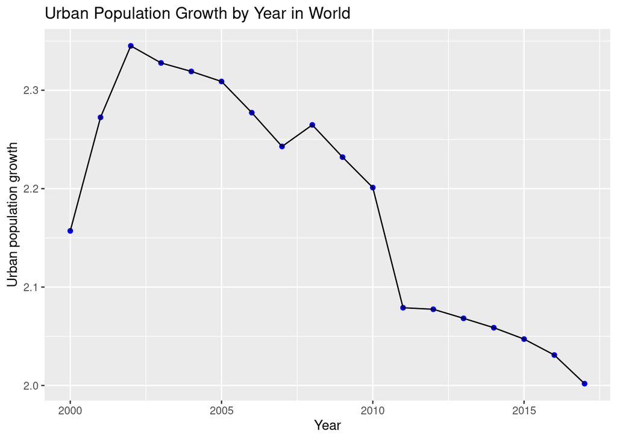

```r
ggplot(myworld2%>% filter(country=="WLD" & indicator == "SP.URB.GROW"),aes(x= `year`, y= `value`)) + geom_point(size=1.5,color="Blue") + geom_line() + labs(y="Urban population growth",x="Year") + ggtitle("Urban Population Growth by Year in World")
```

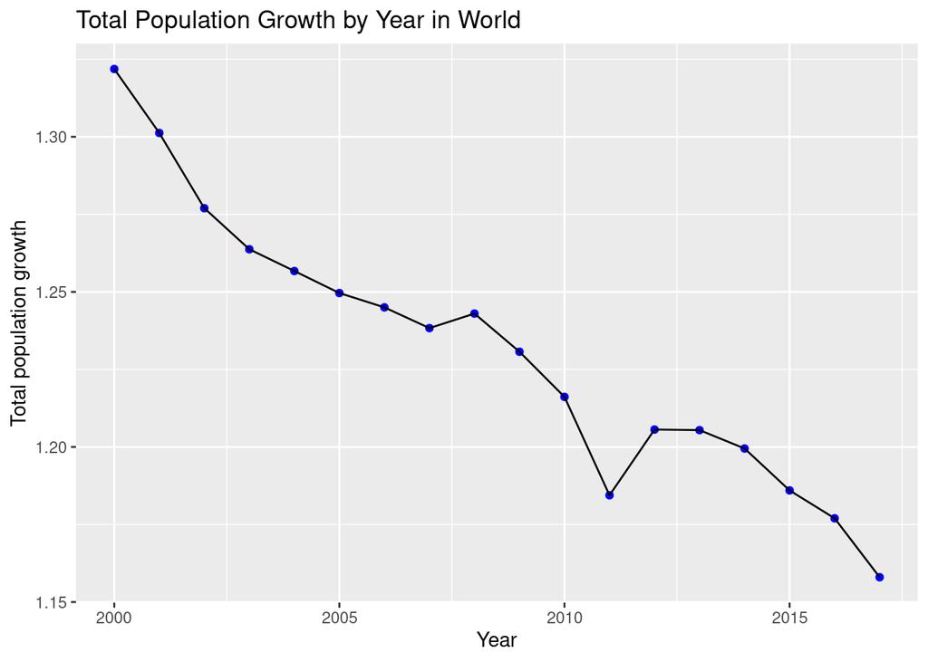

```r
ggplot(myworld2%>% filter(country=="WLD" & indicator == "SP.POP.GROW"),aes(x= `year`, y= `value`)) + geom_point(size=1.5,color="Blue") + geom_line() + labs(y="Total population growth",x="Year") + ggtitle("Total Population Growth by Year in World")
```

##### 1.5 (2 pts) Use one of the `pivot` functions to create a new dataset, `myworld3`, with the different categories for the indicator variable appearing as their own variables. Use `dplyr` functions to rename `SP.POP.GROW` and `SP.URB.GROW`, as `pop_growth` and `pop_urb_growth` respectively. What is the country code that had the highest population growth in 2017?

```r
myworld3 <- myworld2 %>% pivot_wider( names_from= indicator,values_from= value)
myworld3 <- myworld3 %>% rename(pop_growth = SP.POP.GROW, pop_urb_growth = SP.URB.GROW)
myworld3 %>% filter(year==2017) %>% arrange(desc(pop_growth))
```

```
## # A tibble: 264 x 6
##    country  year SP.URB.TOTL pop_urb_growth SP.POP.TOTL pop_growth
##    <chr>   <int>       <dbl>          <dbl>       <dbl>      <dbl>
##  1 OMN      2017     3874061           5.95     4636262       4.67
##  2 BHR      2017     1331176           4.73     1492584       4.62
##  3 NRU      2017       13649           4.50       13649       4.50
##  4 NER      2017     3511546           4.18    21477348       3.82
##  5 GNQ      2017      908248           4.42     1267689       3.71
##  6 AGO      2017    19311773           4.38    29784193       3.31
##  7 UGA      2017     9942492           5.76    42862958       3.26
##  8 COD      2017    35691987           4.57    81339988       3.25
##  9 BDI      2017     1380411           5.72    10864245       3.18
## 10 TZA      2017    18942681           5.28    57310019       3.08
## # … with 254 more rows
```

*OMN has the highest population growth in 2017.*